# **Ataque y Detección MSBuild.exe**

MSBuild.exe tiene una capacidad integrada llamada "Tareas en línea". Estos son fragmentos de código C# que se pueden usar para enriquecer el proceso de compilación de C#. Lo que esto hace es tomar un archivo XML, compilarlo y ejecutarlo en la memoria en el destino.

**Objetivo**

Detectar cuando se ejecuta MSBUILD.exe, intentos de omitir la lista blanca, o de realizar un movimiento lateral utilizando herramientas de desarrollo confiables.

**Categorización**

[Evasión de Defensa](https://attack.mitre.org/techniques/T1127/)

**Estrategia**

- Supervisar registros de Windows Sysmon, para la creación de procesos.
- BUscar ejecución de MSBuild.exe
- Descartarcualquier buen uso.
- Alerta procesos inusuales de MSBild.exe.

## Ejemplo de Evento generado despues de la simulación del ataque.

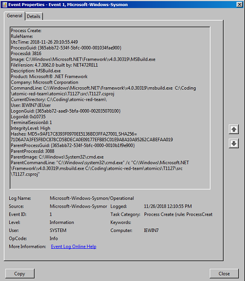

  > python tools/sigmac -t splunk rules/windows/builtin/win_possible_applocker_bypass.yml --config .\tools\config\splunk-windows-all.yml --filter logsource=sysmon --output ./T1127.txt

```
**Splunk Search:**

  (source="WinEventLog:Microsoft-Windows-Sysmon/Operational" EventCode="1"
    (CommandLine="*\\msdt.exe*" OR CommandLine="*\\installutil.exe*" OR CommandLine="*\\regsvcs.exe*"
    OR CommandLine="*\\regasm.exe*" OR CommandLine="*\\regsvr32.exe*" OR CommandLine="*\\msbuild.exe*"
    OR CommandLine="*\\ieexec.exe*" OR CommandLine="*\\mshta.exe*"))
```

[output not shown]